# IMDB NLP

Jiaqi Sun, Huifei Xu, Hao He, Yaquan Yang

2022-10-16

In this topic modeling assignment, we use the IMDB Movie Reviews (50K) dataset from Kaggle to analyze the review sentiment and pull out independent topic categories(i.e., movie genre) based on group of keywords.

## 1. The tidy text format

First, we import data and break down each review into a list of words. Here, we tokenize at word level and treat each review as a separate “document”. We manually created a review number for each document since the movie titles for each review are not included in this dataset. Capitalization in reviews is kept for the initial screening.

```r
IMDB <- read.csv("IMDB Dataset.csv")

IMDB_df <- tibble(IMDB)
# glimpse(IMDB_df)
# two columns: `sentiment` indicates whether the review is labeled negative or
# positive; `review` includes the text of each review.
head(IMDB_df)
```

```
## # A tibble: 6 × 2
##   review                                                                 senti…¹
##   <chr>                                                                  <chr>
## 1 "One of the other reviewers has mentioned that after watching just 1 … positi…
## 2 "A wonderful little production. <br /><br />The filming technique is … positi…
## 3 "I thought this was a wonderful way to spend time on a too hot summer… positi…
## 4 "Basically there's a family where a little boy (Jake) thinks there's … negati…
## 5 "Petter Mattei's \"Love in the Time of Money\" is a visually stunning… positi…
## 6 "Probably my all-time favorite movie, a story of selflessness, sacrif… positi…
## # … with abbreviated variable name ¹sentiment
```

```r
# create review id
IMDB_df %>%
  mutate(review_number = row_number()) ->IMDB_df
```

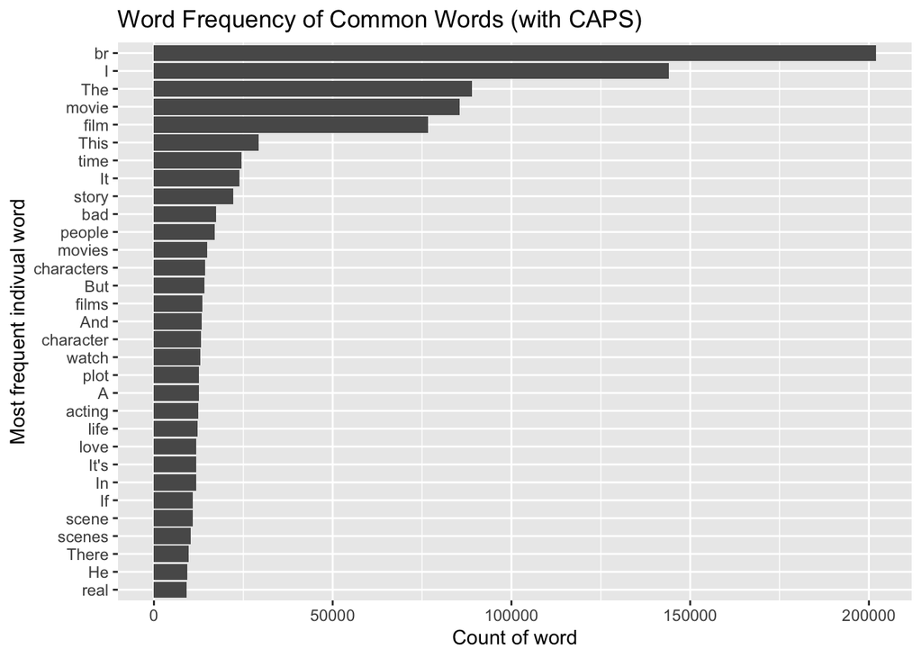

```r
# keep the CAPS for sentiment analysis
tidy_IMDB <- IMDB_df %>%
  unnest_tokens(word, review, to_lower = FALSE)%>% anti_join(stop_words)

# tidy_IMDB

# most common words
# tidy_IMDB %>%
# count(word, sort = TRUE)

#plot frequencies
tidy_IMDB %>%
  count(word, sort = TRUE) %>%
  filter(n > 9000) %>%
  mutate(word = reorder(word, n)) %>%
  ggplot(aes(n, word)) +
  geom_col() +
  labs(y = NULL,
       title = "Word Frequency of Common Words (with CAPS)") +
  xlab("Count of word")+
  ylab("Most frequent indivual word")
```

From the frequency plot above, we can see that if we keep CAPS in each review, the most common words would include some words (such as pronouns) that are useless for sentiment analysis and topic identification, so we decide to lowercase all words.

```r
tidy_IMDB <- IMDB_df %>%
  unnest_tokens(word, review)%>%
  anti_join(stop_words)

head(tidy_IMDB)
```

```
## # A tibble: 6 × 3
##   sentiment review_number word
##   <chr>             <int> <chr>
## 1 positive              1 reviewers
## 2 positive              1 mentioned
## 3 positive              1 watching
## 4 positive              1 1
## 5 positive              1 oz
## 6 positive              1 episode
```

`Stop_words` is a data frame from tidytext package that contains English stop words from three lexicons. Except for these stop-words, we also customize a list of domain specific stop-words.

See below:

Add “br” to be a customized stop-word as it’s a leftover from html format. Add “film”, “movie”, “em” to customized stop-word as they are appearing in any review and meaningless

```r
data(stop_words)
stop_words <- bind_rows(tibble(word = c("br", "film", "movie", "films",
"movies", "characters", "character", "story", "time","people", "watching",
"scene", "scenes", "plot", "watch", "real", "cast", "director", "lot", "pretty",
"10", "actors", "1", "oz", "makes", "2","em"), lexicon = c("custom")),
stop_words)

tidy_IMDB <- tidy_IMDB %>%
  anti_join(stop_words)

head(tidy_IMDB)
```

```
## # A tibble: 6 × 3
##   sentiment review_number word
##   <chr>             <int> <chr>
## 1 positive              1 reviewers
## 2 positive              1 mentioned
## 3 positive              1 episode
## 4 positive              1 hooked
## 5 positive              1 happened
## 6 positive              1 struck
```

After remove all the stop-words, we try stemming and lemmatization. Stemming using rules to cut words down to their stems, operating on the word by itself. Lemmatization uses knowledge about a language’s structure to reduce words down to their lemmas, the canonical or dictionary forms of words, operating on the word in its context. As an important part of NLP pipelines, these methods would help us reduce the feature space of text data and should decrease the sparsity of text data. In this way, we may have a better fitted LDA model in the later process.

```r
# stemming and lemmatization
library(textstem)
lemmatization <- tidy_IMDB %>% mutate(lemma = word%>% lemmatize_words())
lemmatization %>% head()
```

```
## # A tibble: 6 × 4
##   sentiment review_number word      lemma
##   <chr>             <int> <chr>     <chr>
## 1 positive              1 reviewers reviewer
## 2 positive              1 mentioned mention
## 3 positive              1 episode   episode
## 4 positive              1 hooked    hook
## 5 positive              1 happened  happen
## 6 positive              1 struck    strike
```

```r
library(SnowballC)
stemming <- tidy_IMDB %>% mutate(stem = wordStem(word))
stemming %>% head()
```

```
## # A tibble: 6 × 4
##   sentiment review_number word      stem
##   <chr>             <int> <chr>     <chr>
## 1 positive              1 reviewers review
## 2 positive              1 mentioned mention
## 3 positive              1 episode   episod
## 4 positive              1 hooked    hook
## 5 positive              1 happened  happen
## 6 positive              1 struck    struck
```

```r
tidy_IMDB %>%
  count(sentiment, word, sort = TRUE) %>% head()
```

```
## # A tibble: 6 × 3
##   sentiment word       n
##   <chr>     <chr>  <int>
## 1 negative  bad    14706
## 2 positive  love    8669
## 3 negative  acting  8070
## 4 positive  life    8040
## 5 negative  worst   4884
## 6 positive  acting  4772
```

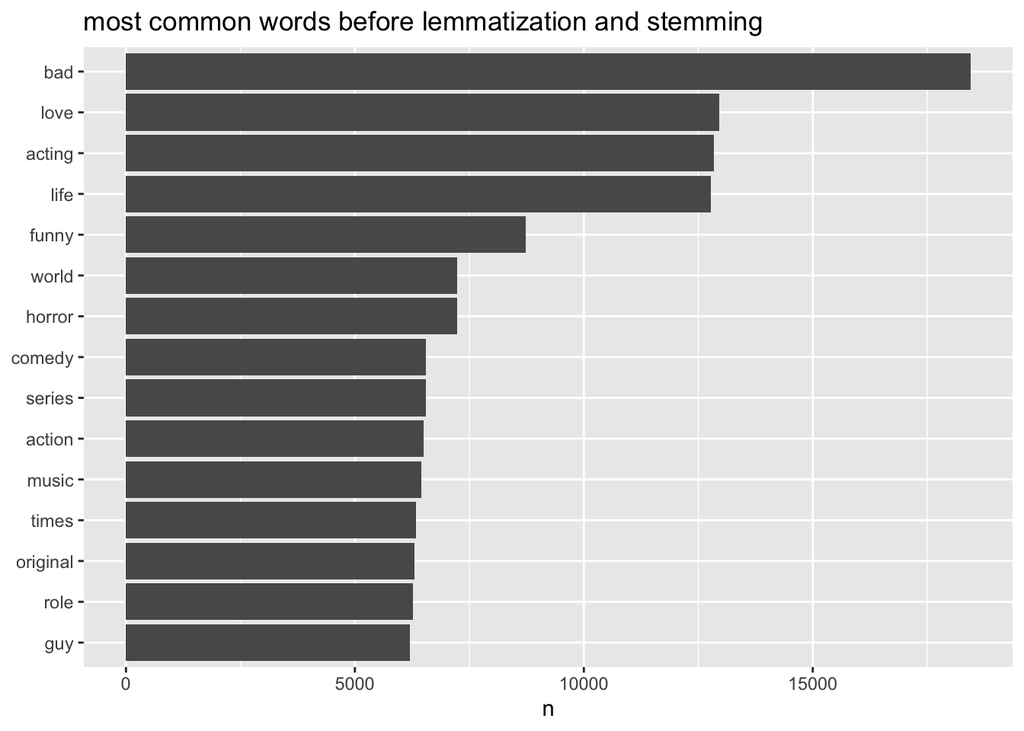

```r
#The most common words in IMDB comments
tidy_IMDB %>%
  count(word, sort = TRUE) %>%
  filter(n > 6000) %>%
  mutate(word = reorder(word, n)) %>%
  ggplot(aes(n, word)) +
  geom_col() +
  labs(y = NULL,title = "most common words before lemmatization and stemming")
```

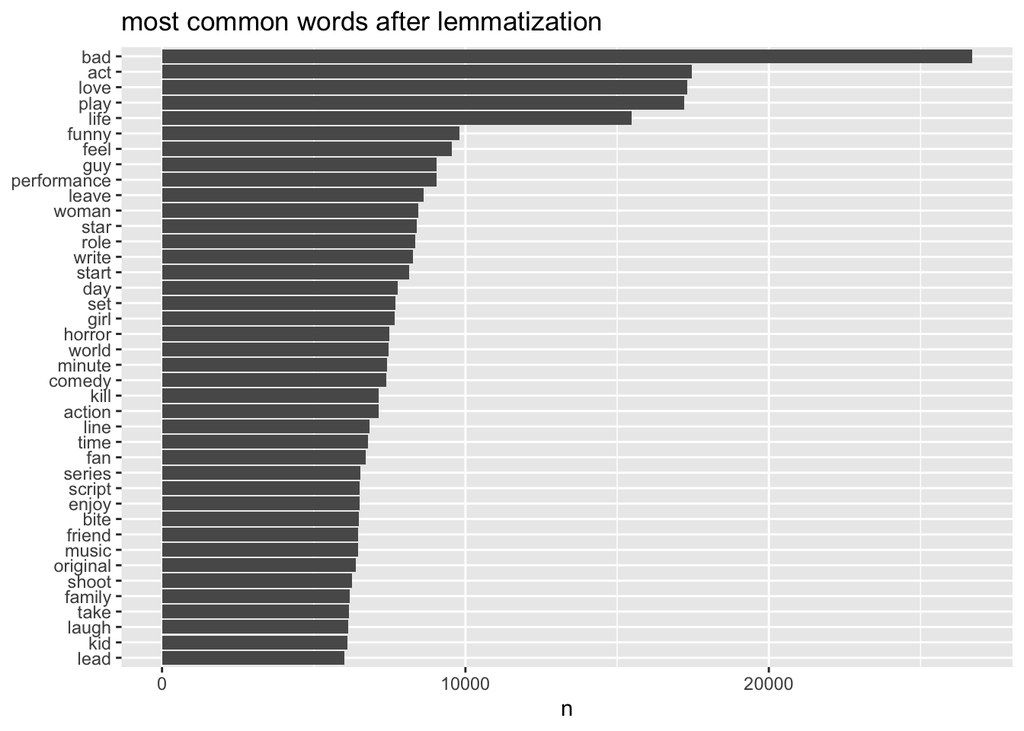

```r
# The most common words after lemmatization
lemmatization %>%
  count(lemma, sort = TRUE) %>%
  filter(n > 6000) %>%
  mutate(lemma = reorder(lemma, n)) %>%
  ggplot(aes(n, lemma)) +
  geom_col() +
  labs(y = NULL, title = "most common words after lemmatization")
```

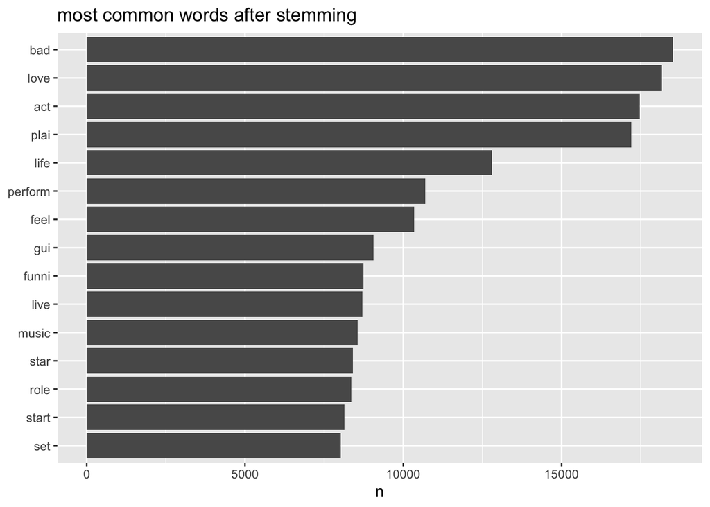

```r
# The most common words after stemming
stemming %>%
  count(stem, sort = TRUE) %>%
  filter(n > 8000) %>%
  mutate(stem = reorder(stem, n)) %>%
  ggplot(aes(n, stem)) +
  geom_col() +
  labs(y = NULL, title = "most common words after stemming")
```

It’s easy to see that stemming would convert “plays” to “plai”, while in lemmatization it would be “play”.

```r
tidy_IMDB %>%
  count(sentiment)
```

```
## # A tibble: 2 × 2
##   sentiment       n
##   <chr>       <int>
## 1 negative  1928848
## 2 positive  2049952
```

## 2. Sentiment analysis with tidy data

```r
bing_word_counts <- tidy_IMDB %>%
  count(word, sentiment, sort = TRUE) %>%
  ungroup()

bing_word_counts %>% head()
```

```
## # A tibble: 6 × 3
##   word   sentiment     n
##   <chr>  <chr>     <int>
## 1 bad    negative  14706
## 2 love   positive   8669
## 3 acting negative   8070
## 4 life   positive   8040
## 5 worst  negative   4884
## 6 acting positive   4772
```

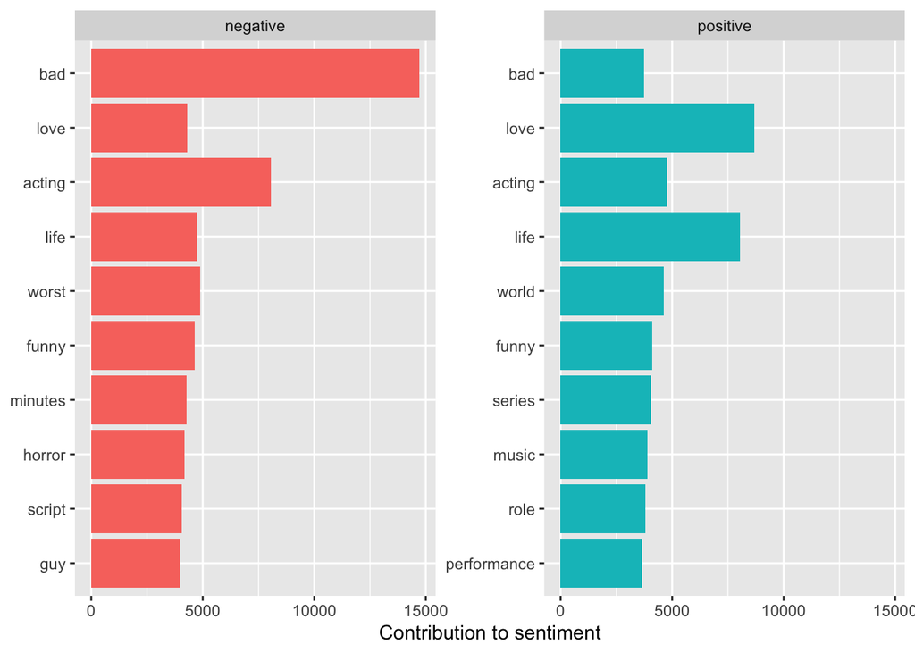

```r
#Words that contribute to positive and negative sentiment in IMDB
bing_word_counts %>%
  group_by(sentiment) %>%
  slice_max(n, n = 10) %>%
  ungroup() %>%
  mutate(word = reorder(word, n)) %>%
  ggplot(aes(n, word, fill = sentiment)) +
  geom_col(show.legend = FALSE) +
  facet_wrap(~sentiment, scales = "free_y") +
  labs(x = "Contribution to sentiment",
       y = NULL)
```

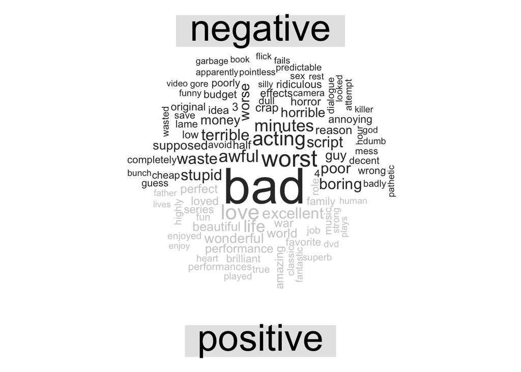

```r
# Most common positive and negative words in IMDB

tidy_IMDB %>%
  count(word, sentiment, sort = TRUE) %>%
  acast(word ~ sentiment, value.var = "n", fill = 0) %>%
  comparison.cloud(colors = c("gray20", "gray80"),
                   max.words = 100)
```

```r
# table(IMDB$sentiment)
```

The polarity function scans the subjectivity lexicon for positive and negative words, and we can further visualize the following results to compare with our sentiment tags. The subjective dictionary used by the qdap package contains about 6800 words with tags, which would be introduced here to help measuring the density of keywords

```
## [1] "C/C/C/C/C/en_US.UTF-8"
```

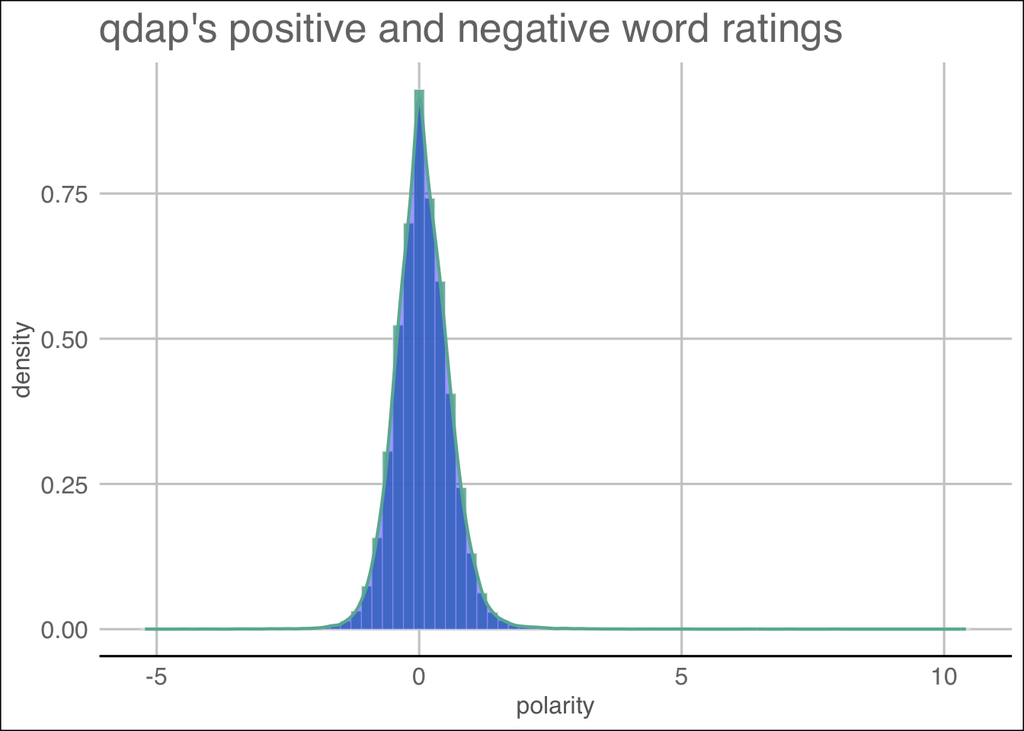

## 3. Analyzing word and document frequency: tf-idf

```r
IMDB_tf_idf <-  tidy_IMDB %>%
  count(review_number, word, sort = TRUE) %>%
  bind_tf_idf(word, review_number, n) %>%
  arrange((tf_idf))

IMDB_tf_idf %>% head()
```

```
## # A tibble: 6 x 6
##   review_number word        n       tf   idf  tf_idf
##           <int> <chr>   <int>    <dbl> <dbl>   <dbl>
## 1         31482 world       1 0.000899  2.22 0.00200
## 2         31437 love        1 0.00117   1.73 0.00202
## 3         31241 love        1 0.00118   1.73 0.00204
## 4         40522 acting      1 0.00140   1.54 0.00217
## 5         31482 tv          1 0.000899  2.47 0.00222
## 6         31482 watched     1 0.000899  2.53 0.00227
```

```r
# summary(IMDB_tf_idf)
```

The inverse document frequency (and thus tf-idf) is very low (near zero) for words that occur in many of the reviews in a collection; this is how this approach decreases the weight for common words. The inverse document frequency will be a higher number for words that occur in fewer of the documents in the collection.

## 4. Relationships between words: n-grams and correlations

```r
IMDB_bigrams <- IMDB_df %>%
  unnest_tokens(bigram, review, token = "ngrams", n = 2) %>%
  filter(!is.na(bigram))

IMDB_bigrams %>% head()
```

```
## # A tibble: 6 x 3
##   sentiment review_number bigram
##   <chr>             <int> <chr>
## 1 positive              1 one of
## 2 positive              1 of the
## 3 positive              1 the other
## 4 positive              1 other reviewers
## 5 positive              1 reviewers has
## 6 positive              1 has mentioned
```

```r
IMDB_bigrams %>%
  count(bigram, sort = TRUE) %>% head
```

```
## # A tibble: 6 x 2
##   bigram          n
##   <chr>       <int>
## 1 br br      101039
## 2 of the      77235
## 3 in the      50216
## 4 this movie  31166
## 5 and the     26639
## 6 is a        26080
```

As one might expect, a lot of the most common bigrams are pairs of common (uninteresting) words, such as of the and to be: what we call “stop-words” (see Chapter 1). This is a useful time to use tidyr’s separate(), which splits a column into multiple based on a delimiter. This lets us separate it into two columns, “word1” and “word2”, at which point we can remove cases where either is a stop-word.

```r
bigrams_separated <- IMDB_bigrams %>%
  separate(bigram, c("word1", "word2"), sep = " ")

bigrams_filtered <- bigrams_separated %>%
  filter(!word1 %in% stop_words$word) %>%
  filter(!word2 %in% stop_words$word)

# new bigram counts:
bigram_counts <- bigrams_filtered %>%
  count(word1, word2, sort = TRUE)

bigram_counts
```

```
## # A tibble: 820,351 x 3
##    word1      word2         n
##    <chr>      <chr>     <int>
##  1 special    effects    2240
##  2 low        budget     1812
##  3 sci        fi         1384
##  4 bad        acting      657
##  5 bad        guys        656
##  6 tv         series      587
##  7 bad        guy         573
##  8 production values      562
##  9 highly     recommend   553
## 10 world      war         529
## # ... with 820,341 more rows
```

bigram and visualisation for negative, positive remarks

```
## # A tibble: 465,153 x 3
##    word1   word2           n
##    <chr>   <chr>       <int>
##  1 special effects       804
##  2 sci     fi            620
##  3 low     budget        592
##  4 highly  recommend     502
##  5 world   war           380
##  6 highly  recommended   372
##  7 tv      series        337
##  8 top     notch         295
##  9 kung    fu            271
## 10 science fiction       257
## # ... with 465,143 more rows
```

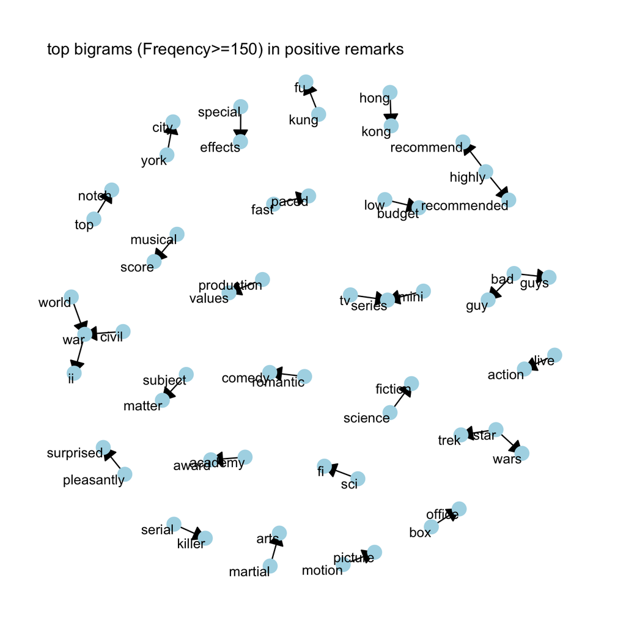

top bigram graph in negative remarks

```
## # A tibble: 416,404 x 3
##    word1      word2       n
##    <chr>      <chr>   <int>
##  1 special    effects  1436
##  2 low        budget   1220
##  3 sci        fi        764
##  4 bad        acting    603
##  5 bad        guys      408
##  6 bad        guy       364
##  7 production values    345
##  8 90         minutes   308
##  9 20         minutes   290
## 10 martial    arts      260
## # ... with 416,394 more rows
```

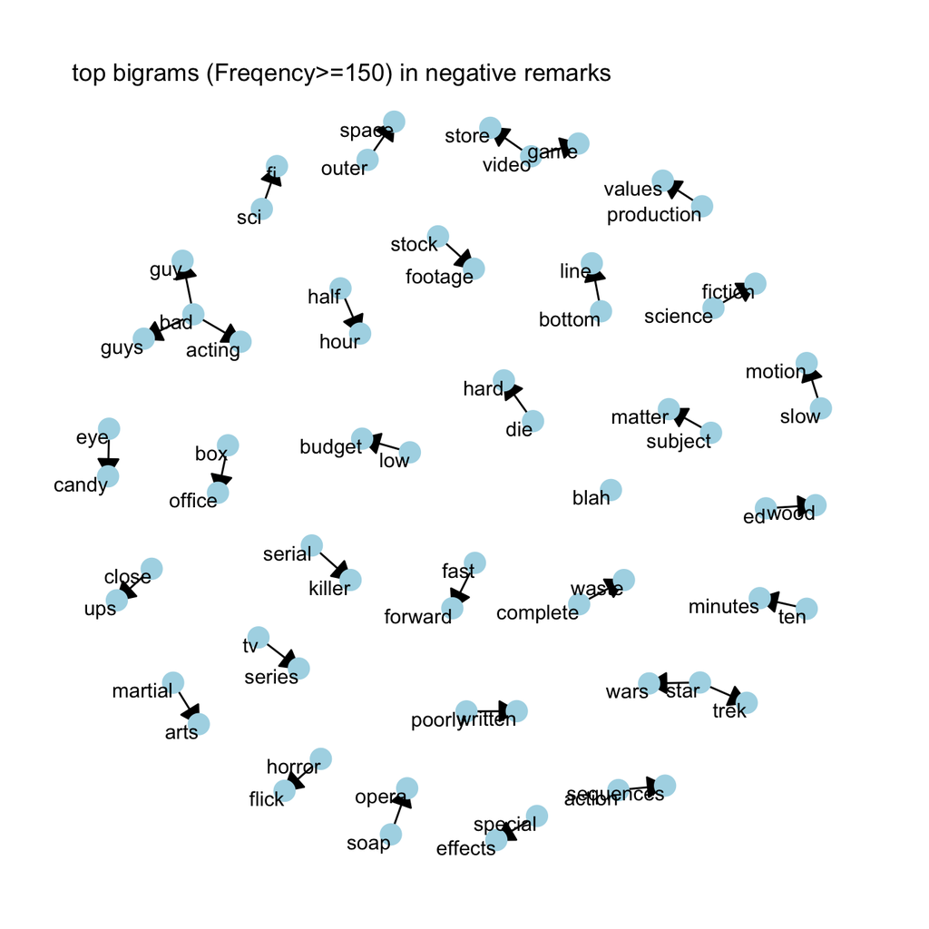

From above two tables and graphs, we found some bigrams present both in negative remarks and positie remarks, for example, bigram of `special` and `effects` occupied the first place in both ranklist!

So we’are about to show top bigrams in positive remarks only and negative remarks only and both in positive and negative remarks as following:

```
## # A tibble: 9 x 4
## # Groups:   remark [3]
##   word1   word2           n remark
##   <chr>   <chr>       <int> <chr>
## 1 bad     acting        603 Negative
## 2 fast    forward       247 Negative
## 3 ten     minutes       221 Negative
## 4 special effects      2240 Negative and Positive
## 5 sci     fi           1384 Negative and Positive
## 6 low     budget       1812 Negative and Positive
## 7 highly  recommend     502 Positive
## 8 world   war           380 Positive
## 9 highly  recommended   372 Positive
```

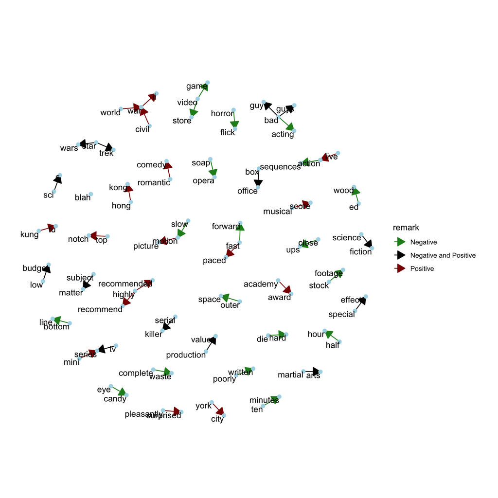

In other analyses, we may want to work with the recombined words. tidyr’s unite() function is the inverse of separate(), and lets us recombine the columns into one. Thus, “separate/filter/count/unite” let us find the most common bigrams not containing stop-words.

```r
bigrams_united <- bigrams_filtered %>%
  unite(bigram, word1, word2, sep = " ")

bigrams_united
```

```
## # A tibble: 1,319,960 x 3
##    sentiment review_number bigram
##    <chr>             <int> <chr>
##  1 positive              1 faint hearted
##  2 positive              1 drugs sex
##  3 positive              1 oswald maximum
##  4 positive              1 maximum security
##  5 positive              1 emerald city
##  6 positive              1 experimental section
##  7 positive              1 glass fronts
##  8 positive              1 aryans muslims
##  9 positive              1 muslims gangstas
## 10 positive              1 gangstas latinos
## # ... with 1,319,950 more rows
```

In other analyses, we may be interested in the most common trigrams, which are consecutive sequences of 3 words. We can find this by setting n = 3:

```r
IMDB_df %>%
  unnest_tokens(trigram, review, token = "ngrams", n = 3) %>%
  filter(!is.na(trigram)) %>%
  separate(trigram, c("word1", "word2", "word3"), sep = " ") %>%
  filter(!word1 %in% stop_words$word,
         !word2 %in% stop_words$word,
         !word3 %in% stop_words$word) %>%
  count(word1, word2, word3, sort = TRUE)
```

```
## # A tibble: 411,042 x 4
##    word1   word2    word3        n
##    <chr>   <chr>    <chr>    <int>
##  1 world   war      ii         230
##  2 sci     fi       channel    164
##  3 low     budget   horror     134
##  4 bad     acting   bad        103
##  5 mystery science  theater     97
##  6 blah    blah     blah        90
##  7 texas   chainsaw massacre    90
##  8 blair   witch    project     84
##  9 local   video    store       80
## 10 tour    de       force       77
## # ... with 411,032 more rows
```

## 5. Converting to and from non-tidy formats

Just as some existing text mining packages provide document-term matrices as sample data or output, some algorithms expect such matrices as input. Therefore, tidytext provides cast_verbs for converting from a tidy form to these matrices.

```r
IMDB_dtm <- tidy_IMDB %>%
  count(review_number, word) %>%
  cast_dtm(review_number, word, n)

IMDB_dtm
```

```
## <<DocumentTermMatrix (documents: 50000, terms: 118916)>>
## Non-/sparse entries: 3423798/5942376202
## Sparsity           : 100%
## Maximal term length: 72
## Weighting          : term frequency (tf)
```

## 6. Topic modeling

This function returns an object containing the full details of the model fit, such as how words are associated with topics and how topics are associated with documents.

```r
# choose number of topics, 6
k = 6

# set a seed so that the output of the model is predictable
IMDB_lda <- LDA(IMDB_dtm, k, control = list(seed = 1234))
IMDB_lda
```

```
## A LDA_VEM topic model with 6 topics.
```

```
#> A LDA_VEM topic model with 6 topics.
```

To start to exploring the lda model, we list the most frequent 30 terms in the topic listed, in rank order.

```
##         Topic 1      Topic 2   Topic 3     Topic 4  Topic 5     Topic 6
## 1        acting         love       bad         bad     love      acting
## 2          life         feel      life        life      bad      series
## 3         funny        funny    acting      comedy     life        feel
## 4         music      minutes    horror      acting      set    original
## 5  entertaining        found      star       funny     role        role
## 6         times          bad     takes     minutes    world         bit
## 7        series        world  terrible       worst    music         guy
## 8        played       horror    action         guy original      played
## 9        comedy       acting      play      script   script          tv
## 10  performance     original       guy         bit    start       music
## 11         hard        death    father         day    woman         fun
## 12         book         evil  american   hollywood     idea       times
## 13          bit  performance     piece    terrible      dvd       worth
## 14         shot performances     lines       times     true         war
```

[output cut: 16 more lines]

The tidytext package provides this method for extracting the per-topic-per-word probabilities, called (“beta”), from the model.

```r
IMDB_topics <- tidy(IMDB_lda, matrix = "beta")
IMDB_topics %>% head()
```

```
## # A tibble: 6 x 3
##   topic term             beta
##   <int> <chr>           <dbl>
## 1     1 accustomed 0.0000102
## 2     2 accustomed 0.0000173
## 3     3 accustomed 0.00000972
## 4     4 accustomed 0.0000175
## 5     5 accustomed 0.0000144
## 6     6 accustomed 0.0000184
```

We could use dplyr’s slice_max() to find the 10 terms that are most common within each topic and create a visualization.

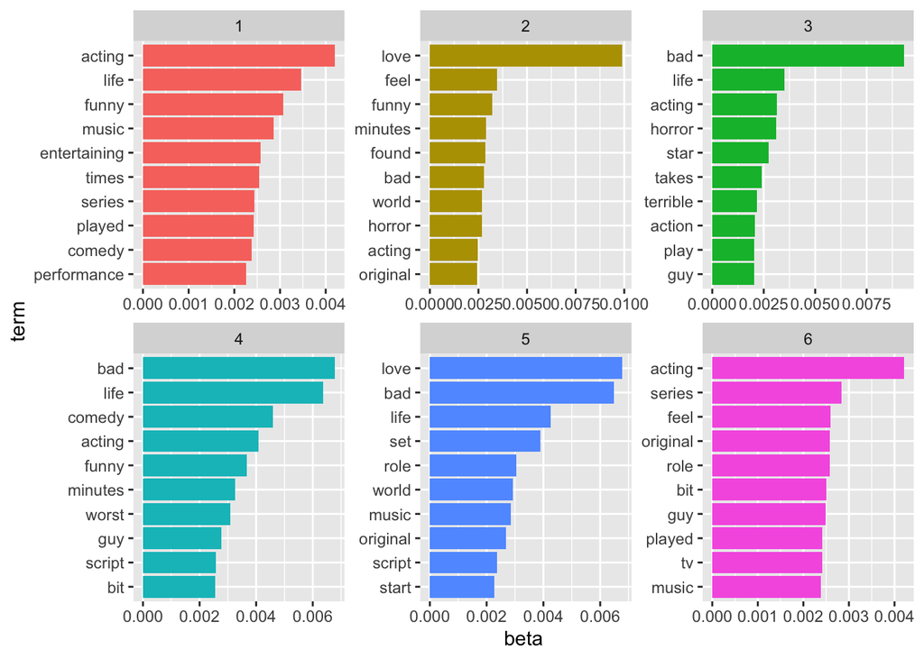

Now we use data after stemming and lemmatization to see if we have an improved results for topic identification. Because stemming would convert “plays” to “plai” which can be confusing for us to interpret the modeling results, we use lemmatized data to fit the model.

```r
# LDA model fitting after stemming and lemmatization

lemma_dtm <- lemmatization%>% count(review_number, lemma) %>%
  cast_dtm(review_number, lemma, n)
# lemma_dtm still has sparsity of 100%, but has less terms: 100852

lemma_lda <- LDA(lemma_dtm, k, control = list(seed = 1234))
lemma_terms <- as.data.frame(topicmodels::terms(lemma_lda, 30),
                             stringsAsFactors = FALSE)
lemma_terms[1:k]
```

```
##     Topic 1     Topic 2  Topic 3     Topic 4     Topic 5 Topic 6
## 1     funny         bad      bad         act         bad    play
## 2      love        love     star         bad performance     bad
## 3      life         guy     life        book      screen     act
## 4      play         day    funny        life         kid    love
## 5      lead       woman     love       write         run    life
## 6    minute        play    start         set        life     kid
## 7      role        role     head        play      moment  reason
## 8      take      minute     feel performance        talk     guy
## 9     leave        feel     hard       world       leave     run
## 10      act         job     line        kill         act    line
## 11 original      action     live     version       begin    girl
## 12      fan        find     take         eye        girl   laugh
## 13     feel         boy   action       funny        time   write
## 14     star       child   series         fun         set  comedy
```

[output cut: 16 more lines]

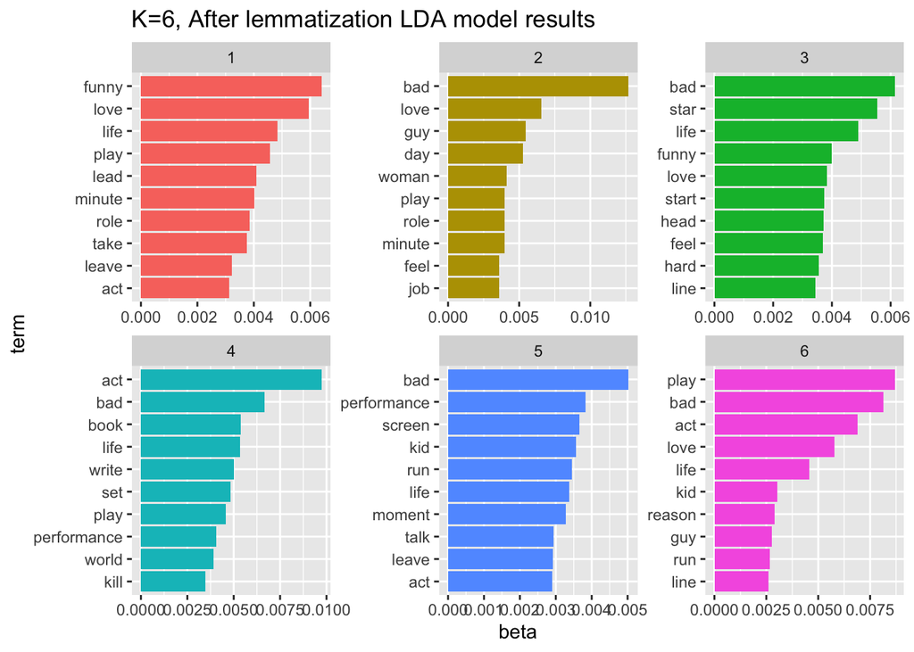

```r
lemma_topics <- tidy(lemma_lda, matrix = "beta")

lemma_top_terms <- lemma_topics %>%
  group_by(topic) %>%
  slice_max(beta, n = 10) %>%
  ungroup() %>%
  arrange(topic, -beta)

lemma_top_terms %>%
  mutate(term = reorder_within(term, beta, topic)) %>%
  ggplot(aes(beta, term, fill = factor(topic))) +
  geom_col(show.legend = FALSE) +
  facet_wrap(~ topic, scales = "free") +
  scale_y_reordered()+
  labs(title = "K=6, After lemmatization LDA model results")
```

```
##        Topic 1      Topic 2   Topic 3     Topic 4  Topic 5     Topic 6
## 1       acting         love       bad         bad      bad      acting
## 2        music      minutes    acting      acting     love         bit
## 3        funny        funny    horror        life    world       music
## 4          bit        world    father     minutes    music        role
## 5        times       acting      life      comedy     life      played
## 6       played         feel      star       worst     role      series
## 7         life       horror  american       funny      set          tv
## 8  performance        worst     world         bit original    original
## 9       screen     original     takes      script     true       worth
## 10        book  performance      play         guy      dvd       times
## 11       actor        sense       guy         day   script        true
## 12      series          bad      dead       times    worst         guy
## 13       enjoy       family  terrible       sense   family        feel
## 14      comedy        enjoy     money        read     live         war
```

[output cut: 47 more lines]

```
##     Topic 1     Topic 2  Topic 3     Topic 4     Topic 5 Topic 6 Topic 7
## 1      love         bad      bad         act         bad    play     bad
## 2     funny        love     life         bad performance     bad    life
## 3      life         day     love        life        life     act     act
## 4      play         guy     star        book        girl    love    play
## 5      role       woman   action         set      horror    life    star
## 6      take      action   horror        play         kid    girl   woman
## 7  original        play     line performance      friend   laugh    love
## 8     leave        role     feel       world         act  reason    role
## 9       act        find     live       write      screen  horror     kid
## 10    woman        girl    shoot     version       leave     kid     day
## 11   script        feel     main         fun       laugh    line     job
## 12     line         fun    start        kill         run  comedy   music
## 13   happen      friend    funny        bite     version    mind  effect
## 14     feel         act   series        time       begin     guy    find
```

[output cut: 47 more lines]

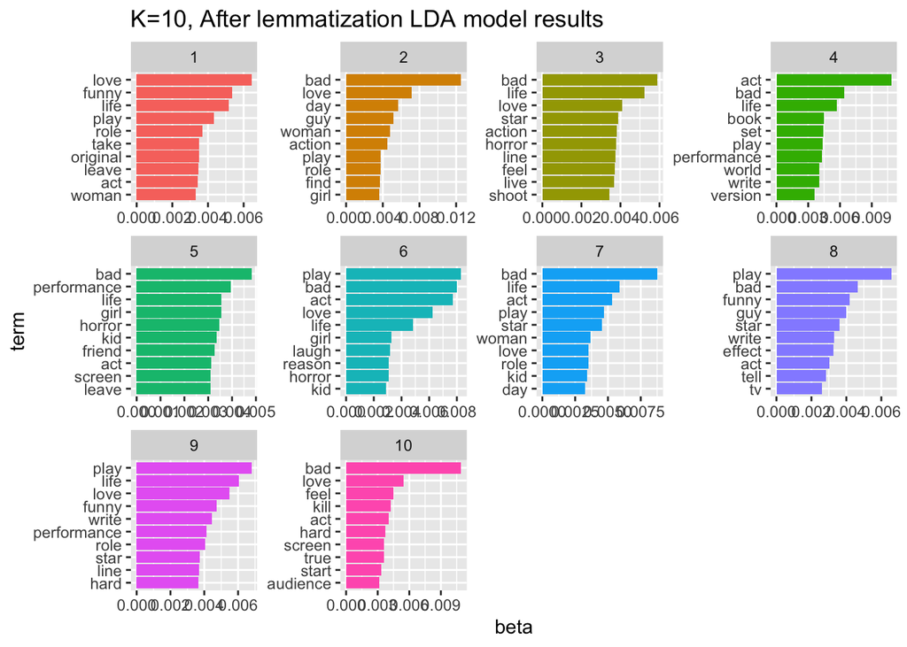

Besides estimating each topic as a mixture of words, LDA also models each document as a mixture of topics. We can examine the per-document-per-topic probabilities, called (“gamma”), with the matrix = “gamma” argument to tidy().

```r
IMDB_gamma <- tidy(IMDB_lda, matrix = "gamma")
IMDB_gamma
```

[output not shown]

## 7. Topic Modeling extension: Determine k number of topics

IN section 6, we assume the number of topics to be 6 to conduct the LDA since not pre-topic tags were provided. However, one major aspect of LDA, is that we need to know the exact k number of optimal topics for the documents. In order to accomplish this task, we are going to use a harmonic mean method to determine k based on Martin Ponweiser’s thesis.(see README.md file)

First, we set up the fuction for computing the harmonic mean

```r
# The harmonic mean function
harmonicMean <- function(logLikelihoods, precision = 2000L) {
  llMed <- median(logLikelihoods)
  as.double(llMed - log(mean(exp(-mpfr(logLikelihoods,
                                       prec = precision) + llMed))))
}
```

In order to find the best value for k, we do this over a sequence of topic models with different vales for k. This will generate numerous topic models with different numbers of topics, creating a vector to hold the k values.

```r
up_k <- 10

# We will use a sequence of numbers from 2 to up_k
seqk <- seq(2, up_k, 1)
burnin <- 1000
iter <- 1000
keep <- 50
fitted_many <- lapply(seqk, function(k) topicmodels::LDA(IMDB_dtm, k = k,
method = "Gibbs", control = list(burnin = burnin, iter = iter, keep = keep)))

# extract logliks from each topic
logLiks_many <- lapply(fitted_many, function(L)  L@logLiks[-c(1:(burnin/keep))])

# compute harmonic means
hm_many <- sapply(logLiks_many, function(h) harmonicMean(h))
```

We could visualize the results of harmonic means by plotting the results

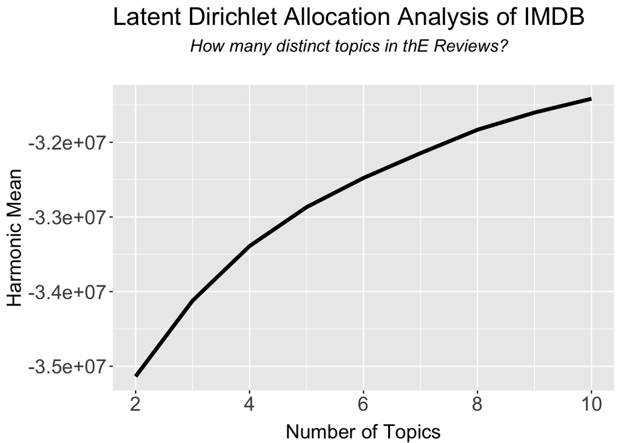

The following code returns the optimal number of topics:

```r
seqk[which.max(hm_many)]
```

```
## [1] 10
```